# Effects of Loan Characteristics on Their Borrower APR

## Investigation Overview

In this investigation, I wanted to look at the characteristics of loans that could be used to predict their borrower Annual Percentage Rate (APR). The main focus was on employment and income characters, credit score and loan amount.

## Dataset Overview

The data from Prosper consisted of 113,937 loans with 81 characteristics. Most characteristics are numeric or dates in nature, but some are categories and texts like occupation.

## Distribution of Borrower APR

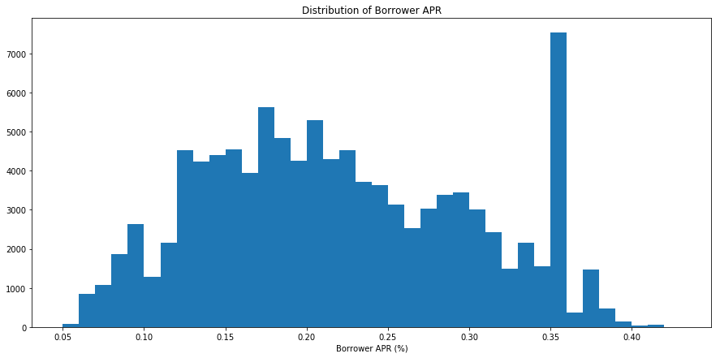

```python
bin_size = 0.01
bins = np.arange(0.05, loans['BorrowerAPR'].max()+bin_size, bin_size)

plt.figure(figsize=[15, 7])
plt.hist(data = loans, x = 'BorrowerAPR', bins = bins)
plt.title('Distribution of Borrower APR')
plt.xlabel('Borrower APR (%)')
plt.show()
```

## Borrower APR vs Income Range

Looking at how income range effects borrower APR, I created a violin plot. The plot clearly shows a gradual change in the distribution shape for each income range. Borrower APR becomes more condensed within the lower ranges (0.05% - 0.2%) where the income peaks. For lower income ranges, borrower APR condenses within the higher ranges (0.3% - 0.45%). To conclude, generally, the higher the income, the lower the borrower APR.

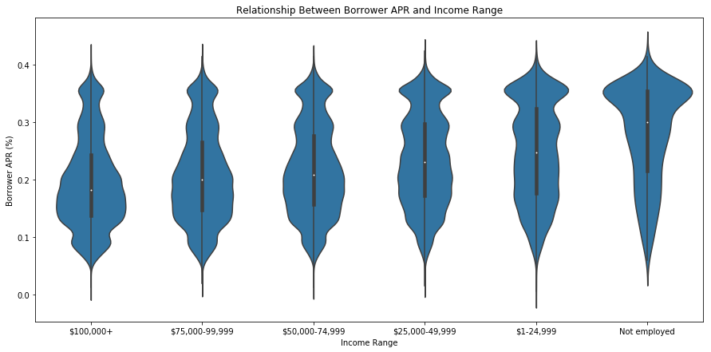

```python
default_color = sb.color_palette()[0]

plt.figure(figsize=[15, 7])
sb.violinplot(data = loans, x = 'IncomeRange', y = 'BorrowerAPR', color = default_color)
plt.title('Relationship Between Borrower APR and Income Range')
plt.xlabel('Income Range')
plt.ylabel('Borrower APR (%)')
plt.show()
```

## Borrower APR vs Income Verifiable

Income verifiable has a strong influence on borrower APR. Even though 92.54% of loan income are verifiable, it is clear from the distributions below, that when the income is not verifiable, the borrower APR is generally much higher. The opposite doesn't however apply. Having a verifiable income doesn't confidently mean that the borrower APR will be low. This is because the distribution where income is verifiable still shows a cluster at a higher borrower APR range.

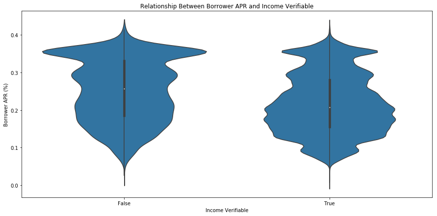

```python
default_color = sb.color_palette()[0]

plt.figure(figsize=[15, 7])
sb.violinplot(data = loans, x = 'IncomeVerifiable', y = 'BorrowerAPR', color = default_color)
plt.title('Relationship Between Borrower APR and Income Verifiable')
plt.xlabel('Income Verifiable')
plt.ylabel('Borrower APR (%)')
plt.show()
```

## Borrower APR vs Credit Score

Borrower APR and the mean credit score has a negative correlation with a correlation coefficient of -0.488. We can see from the plot below that loans with lower credit scores tend to have a higher Borrower APR and the opposite applies when the credit score is higher. This was expected. What's interesting here is that credit scores between 600 and 800 have borrower APR in all ranges. This would imply that if the credit score is close to the mean of the distribution, the borrower APR would depend more on other characteristics and the credit score won't be much of a factor.

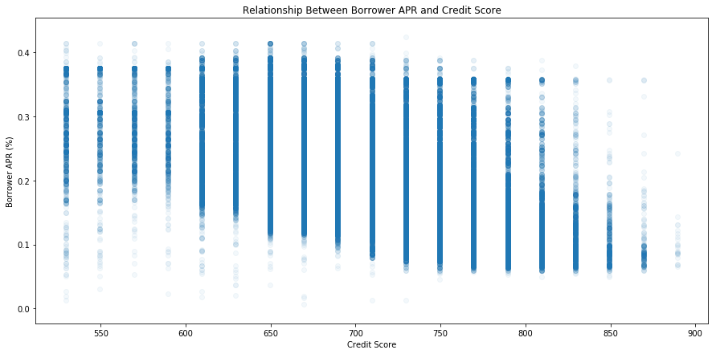

```python
plt.figure(figsize = [15, 7])
plt.scatter(data = loans, x = 'CreditScoreRangeMean', y = 'BorrowerAPR', alpha = 0.05)
plt.title('Relationship Between Borrower APR and Credit Score')
plt.xlabel('Credit Score')
plt.ylabel('Borrower APR (%)')
plt.show()
```

## Borrower APR, Loan Amount and Credit Score

The plot below shows the relation between borrower APR, loan amount and credit score. Unsurprisingly, loan amount and credit score has a positive correlation. As each of them increase, we can visibly see a higher concentration of loans with lower borrower APR.

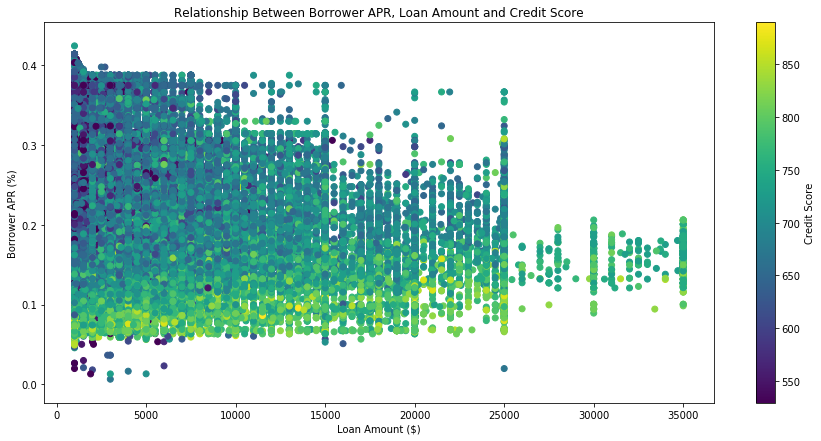

```python
plt.figure(figsize = [15,7])
plt.scatter(data = loans, x = 'LoanOriginalAmount', y = 'BorrowerAPR', c = 'CreditScoreRangeMean')
plt.title('Relationship Between Borrower APR, Loan Amount and Credit Score')
plt.xlabel('Loan Amount ($)')
plt.ylabel('Borrower APR (%)')
plt.colorbar(label='Credit Score')
plt.show()
```